# Project 2

2024-11-14

# Question 1

The data comes from [Ultimate Tennis Statistics](https://ultimatetennisstatistics.com/goatList), a website that stores updated info on every player currently playing on the professional tour and the statistics of those who have played in the past. Many of their datasets include rankings, performance, tournaments, etc, but I chose the GOAT list because I can visualize all of these categories in one dataset that define players holistically. I chose tennis statistics because I started playing tennis when I was three years old, played throughout middle school, and played for varsity throughout high school. Tennis is my ultimate passion and when I grow up I aspire to become a data scientist or analyst for the professional tennis tour, and I feel this was my first chance to try extracting statistics on my favorite players.

[figure not shown]

[Tennis GOAT](https://www.tennismajors.com/atp/nadal-federer-or-so-many-who-is-the-goat-after-roland-garros-298312.html)

# Question 2

I imported the data into R by manually scraping the data into a google spreadsheet, downloading it as a csv file, and then importing it into RStudio with the read.csv function. When I first scraped the data, I had to remove duplicate rows that were redundant for the dataset. Before I analyzed the data, I had to convert the variables that start with a digit into letters in order to make the categories look more aesthetically pleasing. For this, I used the rename function on all of the functions in the dataset using `rename().`I left the numbers in the dataset as is because it was crucial to analyze the amount of points per player in order to determine the player who performed the best.

# Question 3

[output not shown]

# Question 4

### First Univariate Analyses

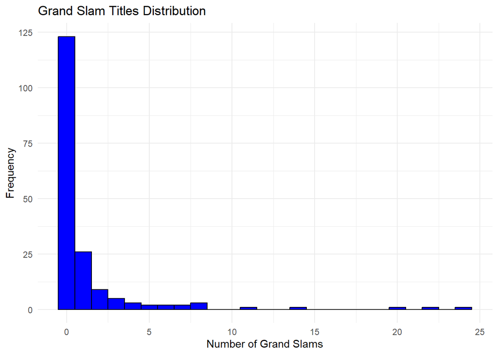

```
##    Min. 1st Qu.  Median    Mean 3rd Qu.    Max.
##   0.000   0.000   0.000   1.233   1.000  24.000
```

This data is skewed right with a mean of approximately 1.233, a minimum of 0, and a maximum of 24. As shown, most players tend to have 0 -5 grand slams. After that, the top 1% of players including Rafael Nadal, Novak Djokovic, and Roger Federer have attained many grand slams despite the odds.

### Second Univariate Analyses

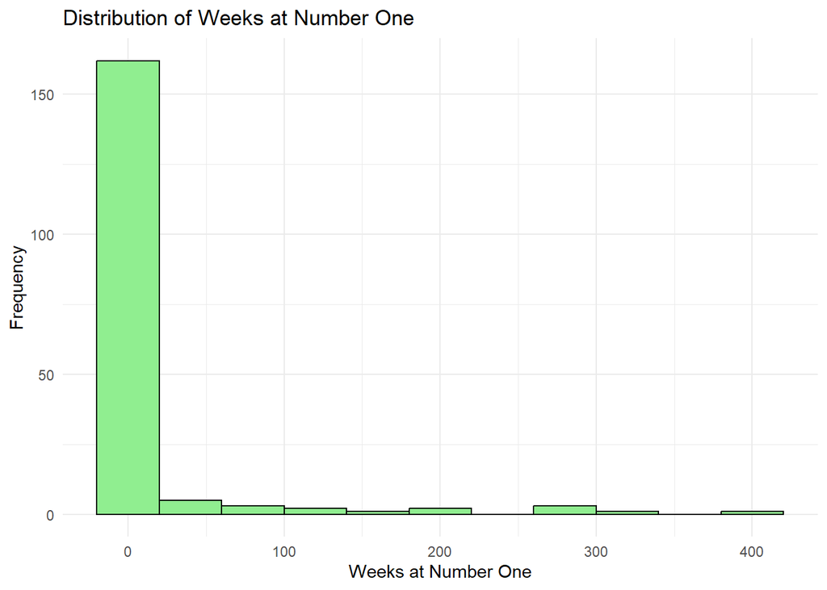

```
##    Min. 1st Qu.  Median    Mean 3rd Qu.    Max.
##    0.00    0.00    0.00   16.09    0.00  404.00
```

As displayed in the histogram, a majority of the players in the tennis dataset have 0 weeks at number one, and only a select amount have more than 0. The data is skewed right, has a mean of 16.09, a minimum of 0, and a maximum of 404 according to the summary statistics `summary(tennis_goat_data$weeks_at_number_one)`. Novak Djokovic, listed as number one on the GOAT rankings according to the dataset, had the most amount of weeks and this is largely considered a factor of impact on the game.

### Third Univariate Analyses

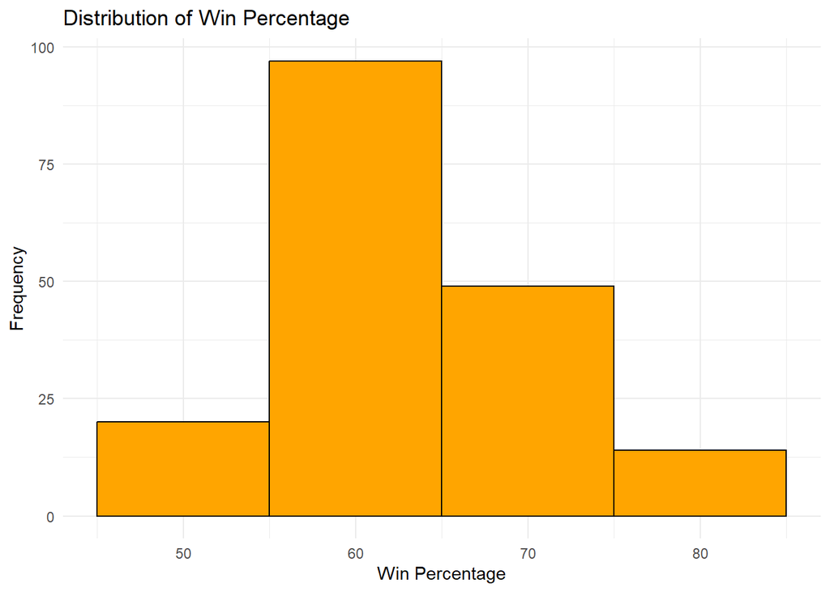

```
##    Min. 1st Qu.  Median    Mean 3rd Qu.    Max.
##   49.20   58.30   62.30   63.32   67.03   83.80
```

As displayed in the histogram above and the program `summary(tennis_goat_data$win_percentage)`, the graph has a mean around 63, a minimum of 49.20, and 83.80. The players with the highest percentages are usually considered the greatest of all time(GOAT), because they are achieving the most amount of victories.

### Fourth Univariate Analyses

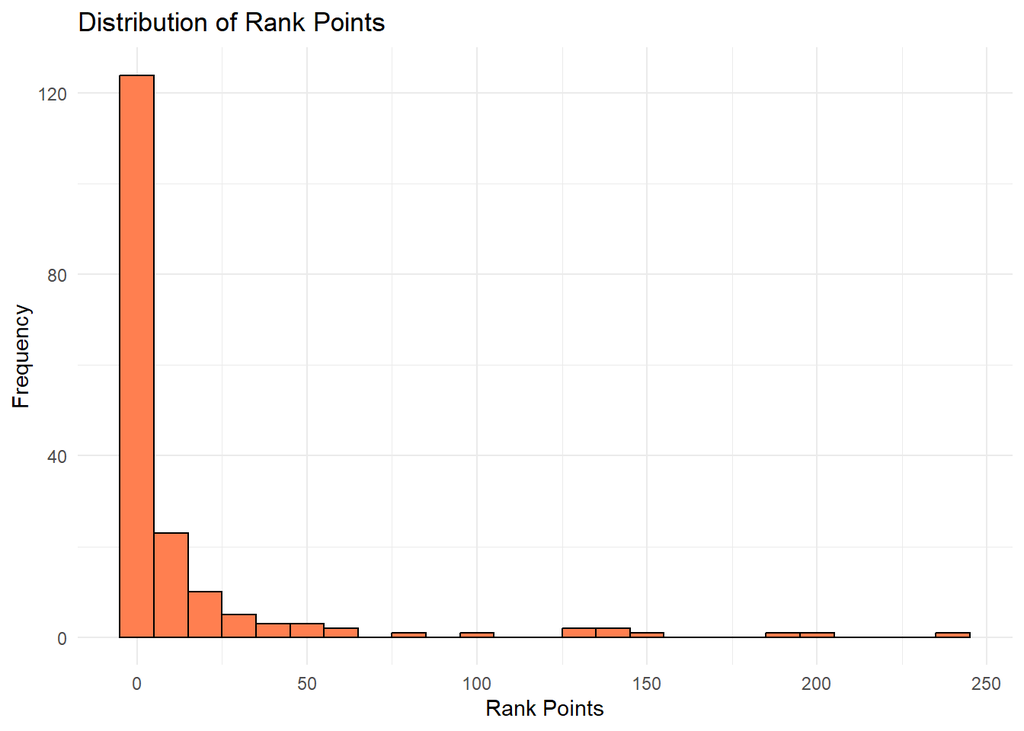

```
##    Min. 1st Qu.  Median    Mean 3rd Qu.    Max.
##    0.00    0.00    2.00   14.47   10.00  241.00
```

The distribution of rank points which is skewed right display that the frequency of players with fewer rank points is very high, specifically around the 0-30 range, and there are far fewer players that have a lot of rank points (above 100). Through the calculation of `summary(tennis_goat_data$rank_points)`, we can see that the mean rank points is around 15.

# Question 5

### First Bivariate Analyses

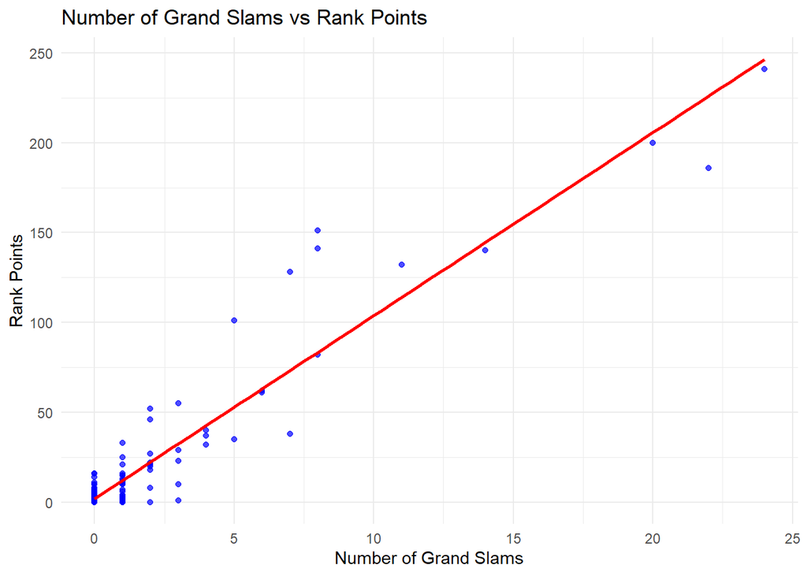

```
## [1] 0.9472883
```

For this scatterplot displaying the relationship between the number of grand slams and total rank points, there is a strong, linear positive correlation between the two variables because of a correlation coefficient of 0.95. `cor(tennis_goat_data$number_grand_slams, tennis_goat_data$rank_points)` was the code I used to generate this number. As seen, players with more grand slams tend to have higher rank points.

### Second Bivariate Analyses

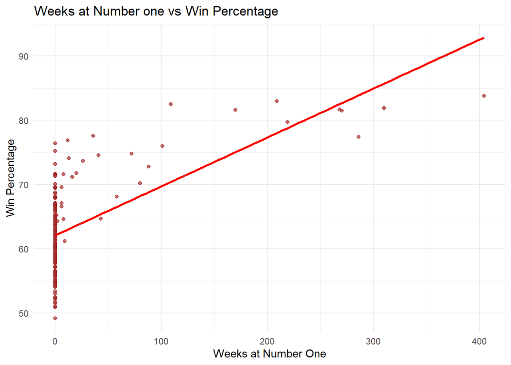

```
## [1] 0.6151069
```

This scatterplot displays the relationship between the weeks at number one and according win percentage of the players, and there is a moderately, positive linear relationship between the variables because of a correlation coefficient of 0.615. The function`cor(tennis_goat_data$weeks_at_number_one, tennis_goat_data$win_percentage)` was utilized to generate this number, and this shows that players who were the longest at the number one rank usually have higher win percentages.

### Third Bivariate Analyses

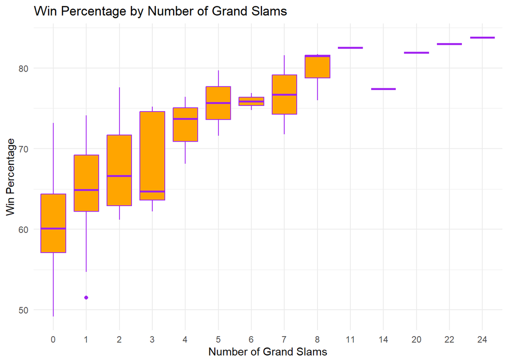

```
##    Group.1     x
## 1        0 60.10
## 2        1 64.90
## 3        2 66.60
## 4        3 64.70
## 5        4 73.70
## 6        5 75.65
## 7        6 75.85
## 8        7 76.70
## 9        8 81.50
## 10      11 82.50
## 11      14 77.40
## 12      20 81.90
## 13      22 83.00
## 14      24 83.80
```

### Fourth Bivariate Analyses

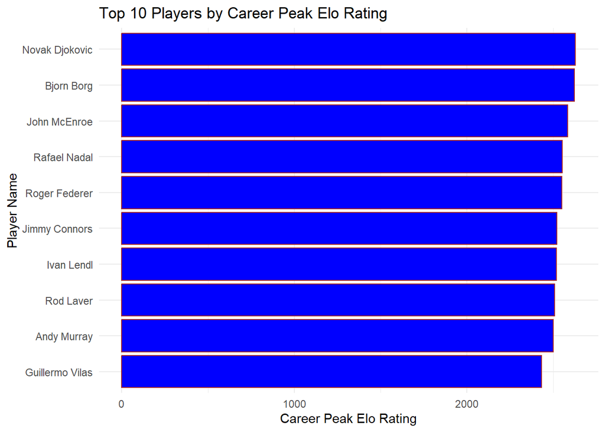

Summary Statistics for Career Peak Elo Ratings

| mean_elo | median_elo | sd_elo | min_elo | max_elo |
| --- | --- | --- | --- | --- |
| 2220.728 | 2196 | 110.8837 | 2050 | 2629 |

This barplot displays the top 10 players of all the players by their Elo rating, which is essentially tracks a player rating that will increase more if they win against higher-rated opponents and less if they win against lower-rated opponents.

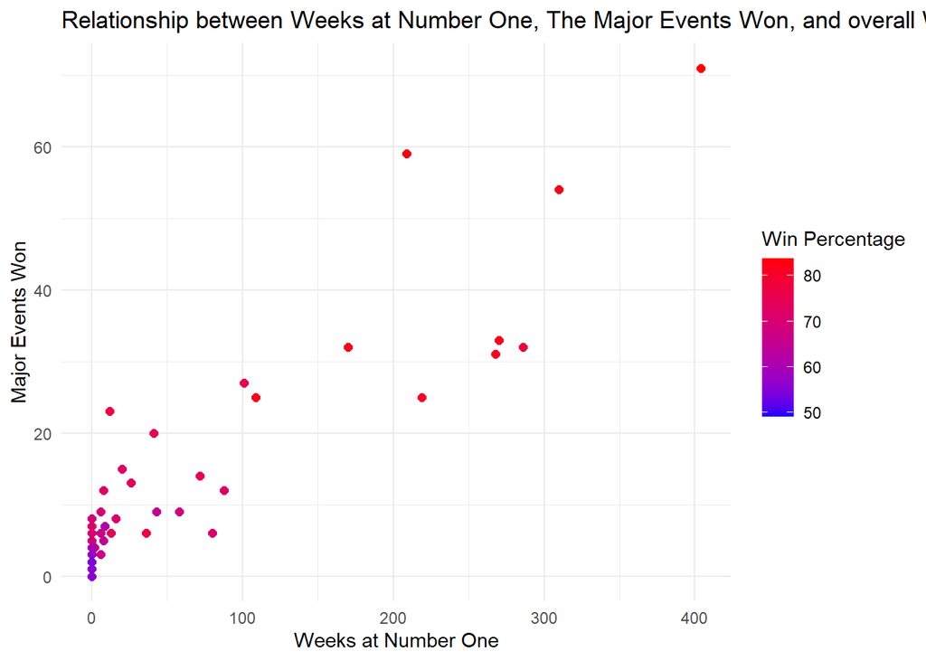

According to the graph, there is a positive correlation between players who have spent more weeks at number one and the amount of major events they have won like ATP 500’s, Master’s, and Futures tournaments. Also, players with higher win percentagges tend to cluster in the upper right area, indicating that a higher dominance at the number one spot usually means high win records and achievements.

## Parsing Variable of Interest

```
## [1] "Novak"  "Roger"  "Rafael" "Jimmy"  "Ivan"   "Pete"
```

## Create at Least Two New Variables of Interest

### Mentions the category of the winning rate

```
## [1] "High Win Rate" "High Win Rate" "High Win Rate" "High Win Rate"
## [5] "High Win Rate" "High Win Rate"
```

Here, I coded a new variable called ‘rate_of_winning’ that categorizes each player into a high win rate, a medium win rate, and a low win rate by their overall win percentage. Displayed above are the first few values of the top few players.

### Adds up all points per player

```
## [1] 1102  924  885  616  604  522
```

Here, I coded a new variable of interest by adding up all the points categories including rank points, achievement points, and tournament points. Displayed above are the first few values of the first few top players. Clearly, the points are displayed in decreasing order.

# Question 6

[Vinay’s Github Project 2 Repository](https://github.com/vinaenae/Project-2.git) - Here is my private github repository. The files it comprises of include the Project 2 RMD file, the report that is knit in HTML, and the csv file that contains the entire tennis GOAT dataset.

# Question 7

There are various elements out of the list provided that I decided to utilize, and they all helped in making my report of the tennis GOAT dataset look aeshetically pleasing. For part C, I reshaped the dataset variable ‘Name’ to the top 10 players in order to capture the main essence of the project: greatest tennis players of all time. I filtered using arrange and utilized the slice function in the last barplot from question 5 that depicted the Top 10 Players by Career Peak Elo Rating. In addition to, for part A, I used 5 in-line codes within my report, and they are scattered throughout my code or graph descriptions from questions 4 and 5. Also, I did Part I by creating a multivariate plot of the variables weeks at number one, major events won, and win percentage. For Part G, I parsed the strings of the player names and retrieved only the first names of the players into a new variable. For Part D, I created two new variables of interests - one that mentions the category of the player winning rate and another that adds up all the points per player.

# Question 8

# References

1.Wickham, Hadley, and Garrett Grolemund. R for Data Science. O’Reilly Media, 2017.

2.Elo Rating System.” Wikipedia, Wikimedia Foundation, 15 Nov. 2024, https://en.wikipedia.org/wiki/Elo_rating_system.

3.Wickham, Hadley. “ggplot2: Elegant Graphics for Data Analysis.” ggplot2 Documentation, 2021, https://ggplot2.tidyverse.org/.

4.RStudio Team. “dplyr: A Grammar of Data Manipulation.” dplyr Documentation, RStudio, https://dplyr.tidyverse.org/.

5.”Case_when Function.” dplyr.tidyverse.org, 2021, https://dplyr.tidyverse.org/reference/case_when.html

6.”Who Is the Best Men’s Tennis Player Ever? The GOAT Debate: Federer, Nadal, Djokovic.” Sporting News, 15 Nov. 2024, www.sportingnews.com/us/tennis/news/who-best-mens-tennis-player-ever-goat-federer-nadal-djokovic/r3nitzqeukf4hvxx4jsjvja

7.”GOAT List.” Ultimate Tennis Statistics, 14 Nov. 2024, https://ultimatetennisstatistics.com/goatList